# Analysis of Trapping Length

$$ l_{\mathrm{p}} \simeq 2\times\texttt{per}^2 \tag{1}\label{1}$$

where $l_{\mathrm{p}}$ is the persistence length and $\texttt{per}$ is a computational variable. The approximation is accurate for larger $\texttt{per}$.

```python
import numpy as np
import matplotlib.pyplot as plt
from scipy.optimize import curve_fit
import scipy.io as sio
from IPython.display import display_pdf
#from sklearn import preprocessing

import warnings
#warnings.filterwarnings("ignore") # "default", etc.
```

# Parameters A; Low Number of Trials

- $\texttt{per} = \{[0,2],\,2.5,\,3\}$ - Make this $0$ to have a freely jointed walk, otherwise the bigger this is the stiffer the chain is.
- $\Delta{\texttt{per}} = 0.2$
- $\texttt{iter}=1,\!000$ - number of walks to simulate
- $\texttt{vis}=0$

```python
per = [0, 0.2, 0.4, 0.6, 0.8, 1, 1.2, 1.4, 1.6, 1.8, 2, 2.5, 3]
mean_traptrack = [102.0820, 102.4240, 101.5220, 100.7830, 100.8260, 96.8860, 110.0640, 125.8830, 145.4550, 170.3400, 210.6070, 301.5370, 419.9740]
```

## Some $l_\mathrm{t}$ related plots

### Plotting the mean trapping length as a function of $\mathrm{per}$

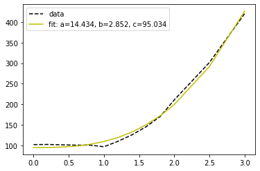

```python
def f(x,a,b,c):
    return a*(x)**b + c

plt.plot(per, mean_traptrack, 'k--', label='data')

popt, pcov = curve_fit(f, per, mean_traptrack)
plt.plot(per, f(per, *popt), 'y-', label='fit: a=%5.3f, b=%5.3f, c=%5.3f' % tuple(popt))

plt.legend()
plt.show()
```

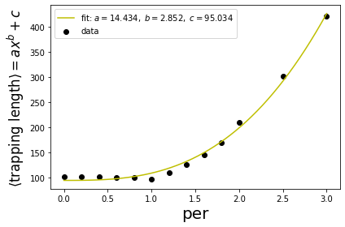

```python
xrange = np.linspace(0,3)  # len(xrange) = 50 by default
pretty_curve = f(xrange, popt[0], popt[1], popt[2])

plt.scatter(per, mean_traptrack, color='black', label='data')
plt.plot(xrange, pretty_curve, color='y', label=rf'fit: $a=%5.3f,~b=%5.3f,~c=%5.3f$' % tuple(popt))

plt.xlabel(r"per", fontsize=20)
plt.ylabel(r"$\left\langle \mathrm{trapping~length} \right\rangle = ax^b+c$", fontsize=16.5)

plt.tight_layout()
plt.legend()
#plt.savefig('plots/mean_traplength_vs_per_iter=1000.pdf', bbox_inches='tight')
plt.show()
```

### Plotting the mean trapping length as a function of $2\times\mathrm{per}^2$

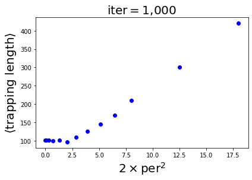

```python
tpt = 2*np.array(per)**2   #2per^2
plt.scatter(tpt, mean_traptrack, color='blue')
plt.xlabel(r"$2\times\mathrm{per}^2$", fontsize=20)
plt.ylabel(r"$\left\langle\mathrm{trapping~length}\right\rangle$", fontsize=20)

plt.tight_layout()
plt.title("$\mathrm{iter} = 1,\!000$", fontsize=20)
#plt.savefig('plots/mean_traplength_vs_2per2_iter=1000.pdf', bbox_inches='tight')
plt.show()
```

### Plotting the mean trapping length as a function of $\left\langle{l_{\mathrm{t}}}\right\rangle \cdot \left(2\times\mathrm{per}^2\right)^{-1}$

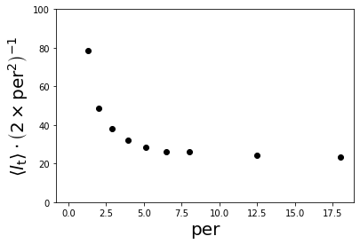

```python
ydata = np.array(mean_traptrack)[1:]/(2*np.array(per)[1:]**2)
plt.scatter(tpt[1:], ydata, color='black')

plt.xlabel(r"per", fontsize=20)
plt.ylabel(r"$\left\langle l_{\mathrm{t}} \right\rangle \cdot \left(2\times\mathrm{per}^2\right)^{-1}$", fontsize=20)

plt.ylim(0,100)
plt.show()
```

# Parameters B

- $\texttt{per} = \{[0,2],\,2.5,\,3\}$
- $\Delta{\texttt{per}} = 0.2$
- $\texttt{iter}=10,\!000$ - number of walks to simulate. This should make it $\sqrt{\tfrac{10000}{1000}}$ more accurate compared to when $\texttt{iter}$ was $1,\!000$.
- $\texttt{vis}=0$

```python
per = [0, 0.2, 0.4, 0.6, 0.8, 1, 1.2, 1.4, 1.6, 1.8, 2, 2.5, 3]
mean_traptrack = [101.7639, 102.0710, 100.8470, 99.1917, 98.6998, 100.4629, 108.5152, 121.4380, 143.5246, 170.2265, 201.4978, 311.1031, 437.4629]
```

## Some $l_\mathrm{t}$ related plots

### Plotting the mean trapping length as a function of $\mathrm{per}$

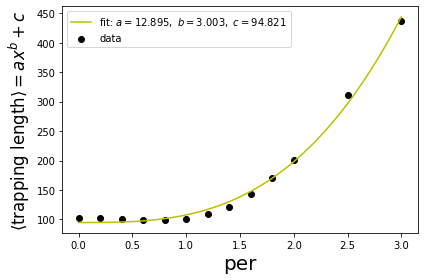

```python
def f(x,a,b,c):
    return a*(x)**b + c

popt, pcov = curve_fit(f, per, mean_traptrack)


xrange = np.linspace(0,3)  # len(xrange) = 50 by default
pretty_curve = f(xrange, popt[0], popt[1], popt[2])

plt.scatter(per, mean_traptrack, color='black', label='data')
plt.plot(xrange, pretty_curve, 'y', label=rf'fit: $a=%5.3f,~b=%5.3f,~c=%5.3f$' % tuple(popt))

plt.xlabel(r"per", fontsize=20)
plt.ylabel(r"$\left\langle \mathrm{trapping~length} \right\rangle = ax^b+c$", fontsize=16.5)

plt.tight_layout()
plt.legend()
#plt.savefig('plots/mean_traplength_vs_per_iter=10000.pdf', bbox_inches='tight')
plt.show()
```

### Plotting the mean trapping length as a function of $2\times\mathrm{per}^2$

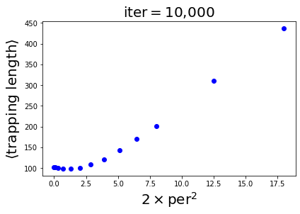

```python
tpt = 2*np.array(per)**2   #2per^2
plt.scatter(tpt, mean_traptrack, color='blue')
plt.xlabel(r"$2\times\mathrm{per}^2$", fontsize=20)
plt.ylabel(r"$\left\langle\mathrm{trapping~length}\right\rangle$", fontsize=20)

plt.tight_layout()
plt.title("$\mathrm{iter} = 10,\!000$", fontsize=20)
#plt.savefig('plots/mean_traplength_vs_2per2_iter=10000.pdf', bbox_inches='tight')
plt.show()
```

### Plotting the mean trapping length as a function of $\left\langle{l_{\mathrm{t}}}\right\rangle \cdot \left(2\times\mathrm{per}^2\right)^{-1}$

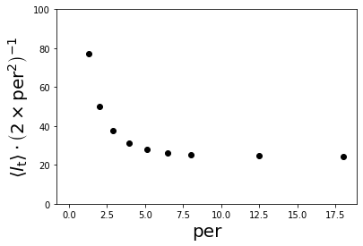

```python
ydata = np.array(mean_traptrack)/(2*np.array(per)**2)
plt.scatter(tpt, ydata, color='black')

plt.xlabel(r"per", fontsize=20)
plt.ylabel(r"$\left\langle l_{\mathrm{t}} \right\rangle \cdot \left(2\times\mathrm{per}^2\right)^{-1}$", fontsize=20)

plt.ylim(0,100)
plt.show()
```

## Histograms

### Importing data for histograms

```python
# >> save('m1.mat', 'm1')
# don't do ">> writematrix(m1, 'm1.txt')"

m1_a = sio.loadmat('data/histogram_data/iter=10000/m1_partial.mat')
m1_b = sio.loadmat('data/histogram_data/iter=10000/m1_per=2.5.mat')
m1_c = sio.loadmat('data/histogram_data/iter=10000/m1_per=3.mat')
m2_a = sio.loadmat('data/histogram_data/iter=10000/m2_partial.mat')
m2_b = sio.loadmat('data/histogram_data/iter=10000/m2_per=2.5.mat')
m2_c = sio.loadmat('data/histogram_data/iter=10000/m2_per=3.mat')

m1 = np.append(np.append(m1_a['m1'], m1_b['m1'], axis=0), m1_c['m1'], axis=0)
m2 = np.append(np.append(m2_a['m2'], m2_b['m2'], axis=0), m2_c['m2'], axis=0)
```

### Plotting the histograms

```
for i in range(len(per)):
    plt.plot(m1[i], m2[i])
    plt.title(f"per = {per[i]}", fontsize=20)
    plt.ylabel("# of simulations", fontsize=20)
    plt.xlabel("trapping length", fontsize=20)
    ##plt.savefig(f'plots/histograms/iter=10000/sim_vs_lt/per={per[i]}-sim_vs_lt_per_2per2.pdf',bbox_inches='tight')
    plt.show()
    if i != len(per) - 1:
        print("\n")
```

```
for i in range(len(per)):
    plt.plot(m1[i]/tpt[i], m2[i])
    plt.title(f"per = {per[i]}", fontsize=20)
    plt.ylabel("# of simulations", fontsize=20)
    plt.xlabel(r"$l_{\mathrm{t}}\cdot \left(2\times\mathrm{per}^2\right)^{-1}$", fontsize=20)
    #plt.savefig(f'plots/histograms/iter=10000/sim_vs_lt_per_2per2/per={per[i]}-sim_vs_lt_per_2per2.pdf',bbox_inches='tight')
    plt.show()
    if i != len(per) - 1:
        print("\n")
```

Using [these](https://www.linuxtut.com/en/6e0898c9128e721d68e3/) lines to display the imported PDF:

```python
with open("plots/histograms/iter=10000/all_in_one_hist_plots.pdf", "rb") as file:
    display_pdf(file.read(),raw=True)
```

[output not shown]

Klotz's instructions: Divide the $x$ values of each one by the mean trapping length so instead of peaking at $120$ or whatever they just peak at $x = 1$ (or close to it), and then normalize them.

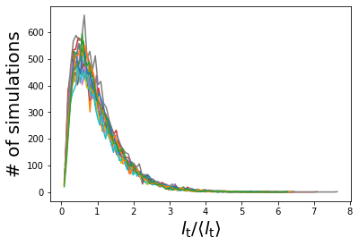

```python
ave_lt = np.array(mean_traptrack)     # ave_lt is just a 'numpy' array of mean_traptrack...

for i in range(len(per)):     # don't need the for loop but it looks better
    plt.plot(m1[i]/ave_lt[i], m2[i])
    #plt.title(f"per = {per[i]}", fontsize=20)
    plt.ylabel("# of simulations", fontsize=20)
    plt.xlabel(r"$l_{\mathrm{t}} / \left\langle l_{\mathrm{t}} \right\rangle$", fontsize=20)
    #plt.savefig(f'plots/histograms/iter=10000/all_in_one_sim_v_lt_per_ave_lt.pdf', bbox_inches='tight')
plt.show()
```

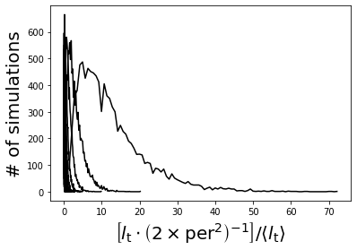

```python
for i in range(len(per)):
    plt.plot((m1[i]/tpt[i])/ave_lt[i], m2[i], color='black')
    #plt.title(f"per = {per[i]}", fontsize=20)
    plt.ylabel("# of simulations", fontsize=20)
    plt.xlabel(r"$\left[l_{\mathrm{t}} \cdot \left(2\times\mathrm{per}^2\right)^{-1}\right] / \left\langle l_{\mathrm{t}} \right\rangle$", fontsize=20)
    #plt.savefig(f'plots/histograms/iter=10000/all_in_one_sim_v_lt_per_tpt_per_ave_lt.pdf', bbox_inches='tight')
plt.show()
```

Based on the plot above, as $\texttt{per}$ increases, the following decreases;

$$ \left[l_{\mathrm{t}} \cdot \left(2\times\texttt{per}^2\right)^{-1}\right] / \left\langle l_{\mathrm{t}} \right\rangle \tag{2}\label{2} $$

as expected since $\texttt{per}$ is in the denomicator. In otherwords, as the persistance length increases, $\eqref{2}$ decreseases since,

$$ \left[l_{\mathrm{t}} \cdot \left(2\times\texttt{per}^2\right)^{-1}\right] / \left\langle l_{\mathrm{t}} \right\rangle \simeq \dfrac{l_{\mathrm{t}}}{l_{\mathrm{p}} \left\langle l_{\mathrm{t}} \right\rangle} \tag{3}\label{3} $$

$\hspace{1cm}$*...unfortunately, this plot does not seem meaningful...*

Now noramlizing the the plots for $\text{# of simulations}$ vs $l_{\mathrm{t}} \,/ \left\langle l_{\mathrm{t}} \right\rangle$ and fitting a function to it; try:
$$f(x) = a\left(x-\frac{7}{\left\langle l_{\mathrm{t}} \right\rangle}\right)^{b} \exp\left[-c\left(x - \frac{7}{\left\langle l_{\mathrm{t}}\right\rangle}\right)^{\vphantom{l}}\!\right] \tag{4}\label{4}$$
where the number $7$ represents the minimum trapping length (could possibly be $8$, $6$ is used in the code). Do this for all the plots corresponding to different $l_{\mathrm{p}}$. Moreover, from here on define,

$$ l_{\mathrm{p}}^{\prime} \,\equiv\, 2\times\texttt{per}^2 \,\simeq\, l_{\mathrm{p}} \tag{5}\label{5} $$

### Normalizing the area under the curves

The normalization constant $A$:

$$ \begin{align*} 1 = A\int f(x) \,dx \qquad\implies\qquad A &= \dfrac{1}{\left[\sum{f(x)}\right] \cdot \Delta x} \end{align*} $$

([This](https://www.educative.io/edpresso/data-normalization-in-python) is interesting...) Instead,

$$ \text{total area} \propto xy \qquad\implies\qquad 1 \backsimeq \texttt{xdata}\times\left(\frac{\texttt{ydata}}{\text{total area}}\right) $$

in other words, to normalize the area under a curve, divide the $\texttt{ydata}$ by the original total area under the curve.

*The peak of distributions vs mean*

### Plotting the non-normalized fitted curves

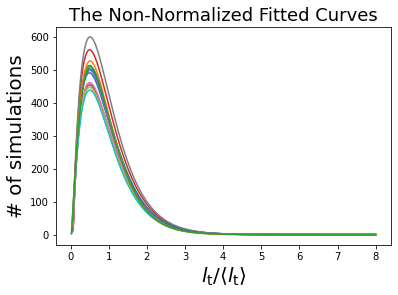

```python
xt = [m1[i]/ave_lt[i] for i in range(len(per))]     # this is just l_t /〈l_t〉

ı = 0     # initiate ı in order to define g
def g(x, a,b,c):
    return a*(x - 6/mean_traptrack[ı])**b * np.exp(-c*(x - 6/mean_traptrack[ı]))

abc_mat_unnorm = [curve_fit(g, xt[ı], m2[ı])[0] for ı in range(len(per))]


χ = np.linspace(0, 8, 500)
gχ, gχ_unnorm = [], []     # lists contanting the data for all the fits and non-normalized fits

for ı in range(len(per)):
    gχ_unnorm.append(g(χ, abc_mat_unnorm[ı][0], abc_mat_unnorm[ı][1], abc_mat_unnorm[ı][2]))
    plt.plot(χ, g(χ, abc_mat_unnorm[ı][0], abc_mat_unnorm[ı][1], abc_mat_unnorm[ı][2]))
plt.title("The Non-Normalized Fitted Curves", fontsize=18)
plt.ylabel("# of simulations", fontsize=20)
plt.xlabel(r"$l_{\mathrm{t}} / \left\langle l_{\mathrm{t}} \right\rangle$", fontsize=20)
plt.show()
```

### Getting the normalized fits and verifying that they are normalized

```python
Δχ = χ[1] - χ[0]
for ı in range(len(per)):     # not sure why list comprehension doesn't work here???
    gχ.append( gχ_unnorm[ı] / round(np.trapz(gχ_unnorm[ı][4:], χ[4:], Δχ), 1) )
    print(f"The area under the normalized fitted curve corresponding to per = {per[ı]}",
          f"is {np.trapz(gχ[ı][4:], χ[4:], Δχ)}.")
```

```
The area under the normalized fitted curve corresponding to per = 0 is 0.9999733512108764.
The area under the normalized fitted curve corresponding to per = 0.2 is 1.0000409549866018.
The area under the normalized fitted curve corresponding to per = 0.4 is 1.000025670863588.
The area under the normalized fitted curve corresponding to per = 0.6 is 1.0000690385866124.
The area under the normalized fitted curve corresponding to per = 0.8 is 1.0000369902481034.
The area under the normalized fitted curve corresponding to per = 1 is 0.9999910707790756.
The area under the normalized fitted curve corresponding to per = 1.2 is 1.0000032339710443.
The area under the normalized fitted curve corresponding to per = 1.4 is 1.0000134946224268.
The area under the normalized fitted curve corresponding to per = 1.6 is 1.0000572774659986.
The area under the normalized fitted curve corresponding to per = 1.8 is 1.00002988990334.
The area under the normalized fitted curve corresponding to per = 2 is 0.9999632844973609.
The area under the normalized fitted curve corresponding to per = 2.5 is 0.9999547847704433.
The area under the normalized fitted curve corresponding to per = 3 is 0.9999815901838921.
```

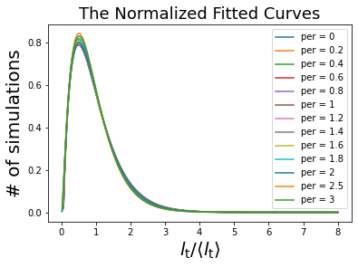

```python
# can safetly start using i as apposed to ı now

for i in range(len(per)):
    plt.plot(χ, gχ[i], label=f"per = {per[i]}")
plt.title("The Normalized Fitted Curves", fontsize=18)
plt.ylabel("# of simulations", fontsize=20)
plt.xlabel(r"$l_{\mathrm{t}} / \left\langle l_{\mathrm{t}} \right\rangle$", fontsize=20)
plt.legend()
#plt.savefig('plots/histograms/iter=10000/all_in_one_sim_v_lt_per_tpt_per_ave_lt-normalized.pdf', bbox_inches='tight')
plt.show()
```

#### Extracting the peaks

```python
gχ_with_no_nan = []

for i in range(len(per)):
    gχ_with_no_nan.append([])
    for j in gχ[i]:
        if np.isnan(j) == False:
            gχ_with_no_nan[i].append(j)

    print(f"For per = {per[i]} the peak is at {max(gχ_with_no_nan[i])}.")
```

```
For per = 0 the peak is at 0.8076528090428317.
For per = 0.2 the peak is at 0.8163355802976946.
For per = 0.4 the peak is at 0.81596588384185.
For per = 0.6 the peak is at 0.8068426348921716.
For per = 0.8 the peak is at 0.8153543419600148.
For per = 1 the peak is at 0.7896414109442994.
For per = 1.2 the peak is at 0.8075399835174774.
For per = 1.4 the peak is at 0.7994577234096967.
For per = 1.6 the peak is at 0.8110622430423656.
For per = 1.8 the peak is at 0.8200206627981178.
For per = 2 the peak is at 0.7994521475172396.
For per = 2.5 the peak is at 0.8440422015471566.
For per = 3 the peak is at 0.8308466049557688.
```

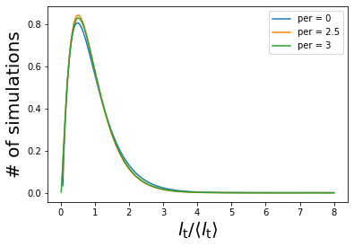

```python
indeces = [0, 11, 12]
for index in indeces:
    plt.plot(χ, gχ[index], label=f"per = {per[index]}")
plt.ylabel("# of simulations", fontsize=20)
plt.xlabel(r"$l_{\mathrm{t}} / \left\langle l_{\mathrm{t}} \right\rangle$", fontsize=20)
plt.legend()
plt.show()
```

# Parameters C; High Number of Trials

- $\texttt{per} = \{[0,2],\,2.5,\,3,\,4\}$
- $\Delta{\texttt{per}} = 0.2$
- $\texttt{iter}=100,\!000$ - number of walks to simulate.
- $\texttt{vis}=0$

```python
per = [0, 0.2, 0.4, 0.6, 0.8, 1, 1.2, 1.4, 1.6, 1.8, 2, 2.5, 3, 4]
mean_traptrack = np.genfromtxt('data/histogram_data/iter=100000/kamdat.txt', skip_header=1, skip_footer=28)
m1 = np.genfromtxt('data/histogram_data/iter=100000/kamdat.txt', skip_header=3, skip_footer=14)
m2 = np.genfromtxt('data/histogram_data/iter=100000/kamdat.txt', skip_header=3+14, skip_footer=0)
```

## Some $l_\mathrm{t}$ related plots

### Plotting the mean trapping length as a function of $\mathrm{per}$

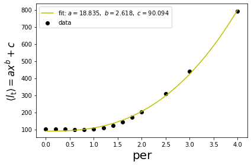

```python
# The function below has already been defined.
#def f(x,a,b,c):
 #   return a*(x)**b + c

popt, pcov = curve_fit(f, per, mean_traptrack)


xrange = np.linspace(0, 4, 200)     # len(xrange) = 50 by default
pretty_curve = f(xrange, popt[0], popt[1], popt[2])

plt.scatter(per, mean_traptrack, color='black', label='data')
plt.plot(xrange, pretty_curve, 'y', label=rf'fit: $a=%5.3f,~b=%5.3f,~c=%5.3f$' % tuple(popt))

plt.xlabel(r"per", fontsize=20)
plt.ylabel(r"$\left\langle l_\mathrm{t} \right\rangle = ax^b+c$", fontsize=16.5)

plt.tight_layout()
plt.legend()
#plt.savefig('plots/mean_traplength_vs_per_iter=100000.pdf', bbox_inches='tight')
plt.show()
```

### Plotting the mean trapping length as a function of $2\times\mathrm{per}^2$

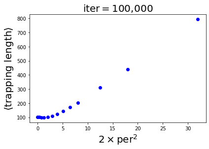

```python
tpt = 2*np.array(per)**2   #2per^2
plt.scatter(tpt, mean_traptrack, color='blue')
plt.xlabel(r"$2\times\mathrm{per}^2$", fontsize=20)
plt.ylabel(r"$\left\langle\mathrm{trapping~length}\right\rangle$", fontsize=20)

plt.tight_layout()
plt.title("$\mathrm{iter} = 100,\!000$", fontsize=20)
#plt.savefig('plots/mean_traplength_vs_2per2_iter=100000.pdf', bbox_inches='tight')
plt.show()
```

### Plotting the mean trapping length as a function of $\left\langle{l_{\mathrm{t}}}\right\rangle \cdot \left(2\times\mathrm{per}^2\right)^{-1}$

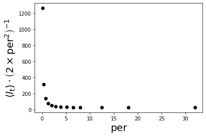

```python
ydata = np.array(mean_traptrack)/(2*np.array(per)**2)
plt.scatter(tpt, ydata, color='black')

plt.xlabel(r"per", fontsize=20)
plt.ylabel(r"$\left\langle l_{\mathrm{t}} \right\rangle \cdot \left(2\times\mathrm{per}^2\right)^{-1}$", fontsize=20)

#plt.ylim(0,100)
plt.show()
```

## Histograms

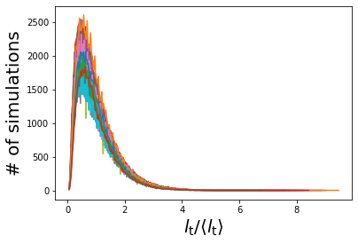

```python
ave_lt = mean_traptrack     # ave_lt is just a 'numpy' array of mean_traptrack...

for i in range(len(per)):     # don't need the for loop but it looks better
    plt.plot(m1[i]/ave_lt[i], m2[i])
    #plt.title(f"per = {per[i]}", fontsize=20)
    plt.ylabel("# of simulations", fontsize=20)
    plt.xlabel(r"$l_{\mathrm{t}} / \left\langle l_{\mathrm{t}} \right\rangle$", fontsize=20)
    #plt.savefig(f'plots/histograms/iter=100000/all_in_one_sim_v_lt_per_ave_lt.pdf', bbox_inches='tight')
plt.show()
```

### Plotting the non-normalized fitted curves

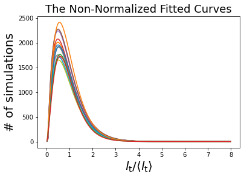

```python
xt = [m1[i]/ave_lt[i] for i in range(len(per))]     # this is just l_t /〈l_t〉

ı = 0     # initiate ı in order to define g
# The function below has already been defined.
#def g(x, a,b,c):
 #   return a*(x - 6/mean_traptrack[ı])**b * np.exp(-c*(x - 6/mean_traptrack[ı]))


abc_mat_unnorm = []     # again, I don't why list comprehension doesn't work :/
for ı in range(len(per)):
    abc_mat_unnorm.append( curve_fit(g, xt[ı], m2[ı])[0] )


χ = np.linspace(0, 8, 500)
gχ, gχ_unnorm = [], []     # lists contanting the data for all the fits and non-normalized fits

for ı in range(len(per)):
    gχ_unnorm.append(g(χ, abc_mat_unnorm[ı][0], abc_mat_unnorm[ı][1], abc_mat_unnorm[ı][2]))
    plt.plot(χ, g(χ, abc_mat_unnorm[ı][0], abc_mat_unnorm[ı][1], abc_mat_unnorm[ı][2]))
plt.title("The Non-Normalized Fitted Curves", fontsize=18)
plt.ylabel("# of simulations", fontsize=20)
plt.xlabel(r"$l_{\mathrm{t}} / \left\langle l_{\mathrm{t}} \right\rangle$", fontsize=20)
plt.show()
```

### Getting the normalized fits and verifying that they are normalized

```python
Δχ = χ[1] - χ[0]
for ı in range(len(per)):     # not sure why list comprehension doesn't work here???
    gχ.append( gχ_unnorm[ı] / round(np.trapz(gχ_unnorm[ı][4:], χ[4:], Δχ), 1) )     # note the 4 is cuz 'nan'
    print(f"The area under the normalized fitted curve corresponding to per = {per[ı]}",
          f"is {np.trapz(gχ[ı][4:], χ[4:], Δχ)}.")
```

```
The area under the normalized fitted curve corresponding to per = 0 is 1.000003907981431.
The area under the normalized fitted curve corresponding to per = 0.2 is 0.9999958662968331.
The area under the normalized fitted curve corresponding to per = 0.4 is 1.0000165701115553.
The area under the normalized fitted curve corresponding to per = 0.6 is 1.000007111586442.
The area under the normalized fitted curve corresponding to per = 0.8 is 0.9999876162502336.
The area under the normalized fitted curve corresponding to per = 1 is 1.0000103927123276.
The area under the normalized fitted curve corresponding to per = 1.2 is 1.0000218457946595.
The area under the normalized fitted curve corresponding to per = 1.4 is 0.9999979949404514.
The area under the normalized fitted curve corresponding to per = 1.6 is 1.0000056157276773.
The area under the normalized fitted curve corresponding to per = 1.8 is 0.9999847535462668.
The area under the normalized fitted curve corresponding to per = 2 is 0.9999908096871376.
The area under the normalized fitted curve corresponding to per = 2.5 is 0.9999955675024416.
The area under the normalized fitted curve corresponding to per = 3 is 1.0000009850334766.
The area under the normalized fitted curve corresponding to per = 4 is 0.9999974119550238.
```

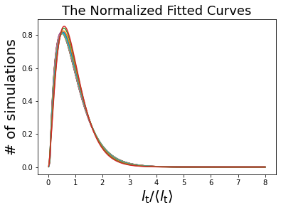

```python
# can safetly start using i as apposed to ı now

for i in range(len(per)):
    plt.plot(χ, gχ[i], label=f"per = {per[i]}")
plt.title("The Normalized Fitted Curves", fontsize=18)
plt.ylabel("# of simulations", fontsize=20)
plt.xlabel(r"$l_{\mathrm{t}} / \left\langle l_{\mathrm{t}} \right\rangle$", fontsize=20)
#plt.legend(loc=1)
#plt.savefig('plots/histograms/iter=100000/all_in_one_sim_v_lt_per_tpt_per_ave_lt-normalized.pdf', bbox_inches='tight')
plt.show()
```

#### Extracting the peaks

```python
gχ_with_no_nan = []

for i in range(len(per)):
    gχ_with_no_nan.append([])
    for j in gχ[i]:
        if np.isnan(j) == False:
            gχ_with_no_nan[i].append(j)

    print(f"For per = {per[i]} the peak is at {max(gχ_with_no_nan[i])}.")
```

```
For per = 0 the peak is at 0.8181982077639376.
For per = 0.2 the peak is at 0.8148927059982908.
For per = 0.4 the peak is at 0.8130744987016685.
For per = 0.6 the peak is at 0.8177207844573168.
For per = 0.8 the peak is at 0.8192995728561397.
For per = 1 the peak is at 0.8131975095617839.
For per = 1.2 the peak is at 0.8125416565935346.
For per = 1.4 the peak is at 0.8077623320582443.
For per = 1.6 the peak is at 0.8094891800181038.
For per = 1.8 the peak is at 0.8110331003286372.
For per = 2 the peak is at 0.8178790632034484.
For per = 2.5 the peak is at 0.825146024482188.
For per = 3 the peak is at 0.8416207131964534.
For per = 4 the peak is at 0.8530514924314824.
```

# Radius of Gyration

$$ R_{\mathrm{g}} = \sqrt{\sum_\imath \sigma_\imath^2 } \tag{6}\label{6} $$

where $\sigma_\imath^2$ is the variance of the $\imath^{\mathrm{th}}$ coordinate's data.

```python
Rg2 = sio.loadmat('data/rg.mat')['rg']
```

$\underline{R}_\mathrm{g}$ is an $m\times n$ matrix whose the *rows* are chains with different trapping lengths and the *columns* are different walks. The matrix of $R_\mathrm{g}$, i.e. $\boldsymbol{{R}_\mathrm{g}}$, where $l$ represents the length and $w$ represents the walk:

$$ \begin{align} \boldsymbol{{R}_\mathrm{g}} = \begin{pmatrix} w_0l_0 & w_1l_0 & \cdots & w_nl_1 \\ w_0l_1 & w_1l_1 & \cdots & w_nl_2 \\ w_0l_2 & w_1l_2 & \cdots & w_nl_3 \\ \vdots & \ddots & \cdots & \vdots \\ w_0l_m & w_1l_m& \cdots & w_nl_m \end{pmatrix} \tag{7}\label{7} \end{align} $$

Here, $m$ is `len(Rg)` which is just $m = 669$; the number of columns (`len(Rg)[#]`) is $n = 16190$.

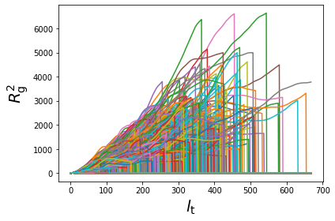

```python
for i in range(len(Rg2[0])):      # "for i in range of the number of walks"
    plt.plot(Rg2[:,i])

plt.ylabel(r"$R_{\mathrm{g}}^2$", fontsize=20)
plt.xlabel(r"$l_{\mathrm{t}}$", fontsize=20)
plt.tight_layout()
#plt.savefig("plots/radius_of_gyration/all_rg2_vs_lt_iter=16190.pdf", bbox_inches='tight')
plt.show()
```

#### Finding the population average as a function of trapping length; the average of all those curves, not including the parts that no longer exist.

Population mean, $\mu$;

$$ \mu = \dfrac{\sum X}{N} \tag{8}\label{8} $$

where $X$ is the individual items in the group and $N$ is the number of items in the group.

In the matrix for $\boldsymbol{{R}_\mathrm{g}}$, eliminate the zeros from each walk as they idicate exactly *nothing*. If the zeros were to not be eliminated, the resulting graph of $\left\langle R_{\mathrm{g}} \right\rangle$ vs $l_{\mathrm{t}}$ would look like:

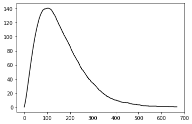

```python
ave_Rg2_WRONG = np.mean(Rg2, axis=1)     # average the rows; i.e., average the different lengths from each independent walk
plt.plot(ave_Rg2_WRONG, color='black')
plt.show()
```

But of course, this would be incorrect. (I just thought it would be interesting to see what it looks like, clearly all the *zeros* are effecting it in a *Gaussian* way!)

### The average radius of gyration

The Matlab code that finds $\left\langle \underline{R}_{\mathrm{g}} \right\rangle^2$ should be:

```
for i = 1:669
  temp = Rg2(i,:);
  temp = temp(temp > 0);
  Rg2_mean(i) = mean(temp);
end
```

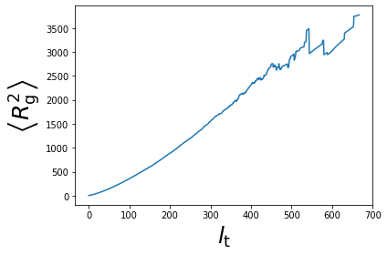

```python
ave_Rg2 = []
temp = []

# start from 1 because first row is just a bunch of zeros...
for m in range(1,len(Rg2)):       # "for m in range the numner of rows of matrix Rg" (669)
    for n in range(len(Rg2[0])):  # "for n in range the mumber of columns of matrix Rg" (16190)
        if Rg2[m,n] != 0:
            temp.append(Rg2[m,n])
    ave_Rg2.append(sum(temp)/len(temp))
    temp = []
del temp


plt.plot(ave_Rg2)
plt.ylabel(r"$\left\langle R_{\mathrm{g}}^2 \right\rangle$", fontsize=25)
plt.xlabel(r"$l_{\mathrm{t}}$", fontsize=25)
plt.tight_layout()
#plt.savefig("plots/radius_of_gyration/ave_rg2_vs_lt_iter=16190.pdf", bbox_inches='tight')
plt.show()
```

*Note that up until here, it was actually $R_{\mathrm{g}}^2$ instead of $R_{\mathrm{g}}$!*

After graphing the ${\langle {R}_{\mathrm{g}}^2 \rangle}$ related plots, to the straight part of the graph, fit a power function $h(x) = ax^b.$ But the interesting quantity is $\langle {R}_{\mathrm{g}} \rangle$ itself and not its square. One cannot simply divide the power law by the exponent of the average radius of gyration as $\langle \zeta \rangle \neq \langle \zeta^b \rangle^{1/b}.$

One solution would be to go back to the beginning and to take the square root of all the elements of $ \boldsymbol{R^2_\mathrm{g}}$; but, it would be more efficient to simply divide the power law found for $\langle R_{\mathrm{g}}^2\rangle\!\left(l_\mathrm{t}\right)$ by $2$, even though it is not the same as $\langle {R}_{\mathrm{g}} \rangle$! This is OK because for a large amount of data they *will* be the same; the variance is $\langle R_\mathrm{g}^2\rangle - \langle R_\mathrm{g}\rangle^2$ and gets relatively smaller with more data. (You can try it yourself with smaller numbers and see how different the results are.)

$$ \lim_{n\to\infty} \sigma^2 = 0 \tag{9}\label{9} $$

where $n$ is number of simulations.

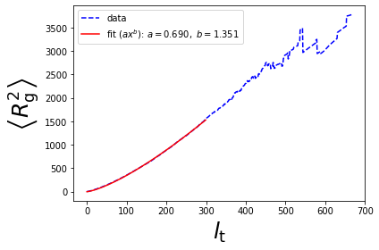

```
   a = 0.689996112710368870 ± 0.005841939348850574
   b = 1.351312331902958075 ± 0.001556724769333615
```

```python
def h(x, a,b):
    return a*x**b

plt.plot(ave_Rg2, 'b--', label='data')
lt = np.linspace(0, len(ave_Rg2)-1, len(ave_Rg2))

# lt is linear and increases by 1 starting from 0, so lt[300] = 300.

popt, pcov = curve_fit(h, lt[0:300], ave_Rg2[0:300])


plt.plot(lt[0:300], h(lt[0:300], *popt), 'r-', label=r'fit $\left(ax^b\right)$: $a=%5.3f,~b=%5.3f$' % tuple(popt))
plt.ylabel(r"$\left\langle R_{\mathrm{g}}^2 \right\rangle$", fontsize=25)
plt.xlabel(r"$l_{\mathrm{t}}$", fontsize=25)
plt.tight_layout()
plt.legend()
#plt.savefig("plots/radius_of_gyration/ave_rg2_vs_lt-fit_iter=16190.pdf", bbox_inches='tight')
plt.show()

print('   a =', "%0.18f" % popt[0], '±', "%.18f" % pcov[0,0]**0.5) #2ND HALF IS FIT UNCERTAINTY
print('   b =', "%0.18f" % popt[1], '±', "%.18f" % pcov[1,1]**0.5)
```

And so the power law for $R_{\mathrm{g}}\!\left(l_\mathrm{t}\right)$ is ${ \tfrac{b}{2} = \underline{0.675656165951479}. }$

### Log–log plot of $\langle {R}_{\mathrm{g}} \rangle$ vs $l_\mathrm{t}$

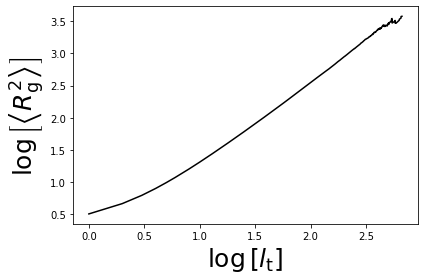

```python
log_lt = np.log10(np.linspace(0, len(ave_Rg2)-1, len(ave_Rg2)))

plt.plot(log_lt, np.log10(ave_Rg2), color='black')
plt.ylabel(r"$\log\,\left[\left\langle R_{\mathrm{g}}^2 \right\rangle\right]$", fontsize=25)
plt.xlabel(r"$\log\,\left[l_{\mathrm{t}}\right]$", fontsize=25)
plt.tight_layout()
#plt.savefig("plots/radius_of_gyration/log_ave_rg_vs_log_lt_iter=16190.pdf", bbox_inches='tight')
plt.show()
```

By eyeballing this plot, it appears that the "straight part" is between $\log l_\mathrm{t} \approx 0.5$ and $\log l_\mathrm{t} \approx 2.5$; the power function $h$ will be fit to that region. To find the indeces of values closest to these numbers, either print out `log_lt` or use `np.where`.  
Using `np.where` to find the index of the first element $\geq 0.5$:

```
>>> np.where(log_lt >= 0.5)[0][0]
```

```
>>> np.where(log_lt <= 2.5)[0][-1]
```

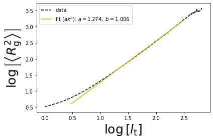

```python
plt.plot(log_lt, np.log10(ave_Rg2), 'k--', label='data')

popt, pcov = curve_fit(h, log_lt[3:315+1], np.log10(ave_Rg2)[3:315+1])
plt.plot(log_lt[3:315+1], h(log_lt[3:315+1], *popt), 'y-', label=r'fit $\left(ax^b\right)$: $a=%5.3f,~b=%5.3f$' % tuple(popt))

plt.legend()
plt.ylabel(r"$\log\,\left[\left\langle R_{\mathrm{g}}^2 \right\rangle\right]$", fontsize=25)
plt.xlabel(r"$\log\,\left[l_{\mathrm{t}}\right]$", fontsize=25)
plt.tight_layout()
#plt.savefig("plots/radius_of_gyration/log_ave_rg_vs_log_lt_iter=16190_power_fit.pdf", bbox_inches='tight')
plt.show()
```

The power law for log–log plot of ${\langle {R}_{\mathrm{g}}^2 \rangle}$ vs $l_\mathrm{t}$ is $b \approx 1$; but that is redundant and is guaranteed to get a value of $1$ because every power function is linear when you take the logarithm.

### Semi–log plot

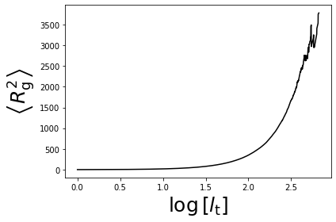

```python
plt.plot(log_lt, ave_Rg2, color='black')
plt.ylabel(r"$\left\langle R_{\mathrm{g}}^2 \right\rangle$", fontsize=25)
plt.xlabel(r"$\log\,\left[l_{\mathrm{t}}\right]$", fontsize=25)
plt.tight_layout()
#plt.savefig("plots/radius_of_gyration/semi-log_ave_rg_vs_log_lt_iter=16190.pdf", bbox_inches='tight')
plt.show()
```

# Testing

## Testing $\texttt{np.trapz}$ & curve normalization

```
The area under the curve below is 4.5.
np.trapz returns 4.5
```

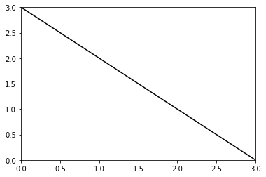

```
The area under the curve below is 1.0. To get this curve, divide the y-axis of the curve above by its area.
np.trapz returns 1.0
```

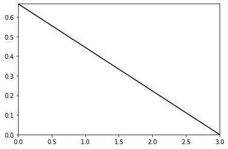

```
np.trapz returns 1.0
```

```python
def y(x):
    return -x + 3

x = np.linspace(0,3)
y = y(x)

plt.xlim(0,3)
plt.ylim(0,3)
plt.plot(x, y, color='black')
print(f"The area under the curve below is 4.5.\nnp.trapz returns {round(np.trapz(y,x), 1)}")
plt.show()



y = y/4.5

plt.plot(x, y, color='black')
plt.xlim(min(x), max(x))
plt.ylim(min(y), max(y))
print(f"The area under the curve below is {max(y)*max(x)/2}. To get this curve, divide the y-axis of the curve above",
          f"by its area.\nnp.trapz returns {round(np.trapz(y,x), 1)}")
plt.show()
print('np.trapz returns', round(np.trapz(y,x), 1))
```